# Professional Views of Digital Audio Workstations and Collaborative Audio Mixing

Scott Stickland (School of Humanities, Creative Industries and Social Sciences, The University of Newcastle, Australia)

Rukshan Athauda (School of Information and Physical Sciences, The University of Newcastle, Australia)

Nathan Scott (School of Humanities, Creative Industries and Social Sciences, The University of Newcastle, Australia)

2021-11-12

# 1 Introduction

Professional studio-based audio mixing of recorded material is an innately collaborative process. Rarely is the audio engineer granted carte blanche to produce a mix without some degree of oversight and input from the various stakeholders, including the recording artist(s), music producer(s), recording label representative(s) and, in the case of music for film and television, the composer, music supervisor, editor, producer(s) and director. Today, many modern music production studios centrally integrate a Digital Audio Workstation (DAW) software application in professional audio mixing. Although professional audio mixing with all stakeholders physically in the well-equipped studio with a DAW and audio engineer is ideal, remote collaboration modes and practices for professional audio mixing are highly desirable, especially in coronavirus-impacted times of self-isolation and travel restrictions. This study’s *raison d’être* was to understand the current practices and identify the requirements for an ideal remote collaborative environment for professional audio mixing and post-production. We conducted a series of semi-structured interviews with professional audio mixing and music production engineers to answer this central research question.

This article presents an interpretative phenomenological analysis (IPA) of the responses from the semi-structured interviews. The IPA approach, as defined by Smith (2004), is: ideographic, characterised by a detailed sequential examination of each case in a small sample size; inductive, “to allow unanticipated topics or themes to emerge during analysis” (p. 43); and interrogative, where discussion of the results of the analysis concerns the research project’s context. The interviews were voluntary and aimed to ascertain several viewpoints, including:

- The prevailing use of DAW platforms in audio mixing and music production workflows;
- The range of specific DAW platforms used in the industry;
- Typical professional work-case scenarios;
- The current use of keyboard shortcuts and control surfaces in typical work-case scenarios;
- Use of DAW-integrated online collaboration tools in professional studio work;
- Typical existing practices when working with remote clients/colleagues;
- Industry expectations of a real-time online audio mixing and music production environment; and
- The perceived utility of multiparty audio mixing and music production online collaboration.

Six questions served as the interview guide and discussion starting points and appear in the Appendix. As such, this article’s structure consists of six discrete sections that inductively analyse the responses to the interview questions and any related follow-up questions, followed by a Discussion section. Table 1 summarises the research participant information.

Statistical information on the recruited mixing engineers

[output not shown]

# 2 Participant Responses

## 2.1 DAW Platforms and Their Typical Use

Question 1 firstly concentrated on the participants’ choice of DAW platform(s) to determine the technical sophistication and audio processing capability required of a DAW engaged in professional audio mixing. This question also sought to establish the participants’ typical work-case scenarios and the role their DAW platform(s) played in performing such work to achieve industry-standard results.

### 2.1.1 The Prevailing Use of DAW Platforms

In all nine instances, the engineers’ choice of DAW platform was integral to their daily work. This sample size determined that most studio configurations appeared to be an amalgamation of digital and analogue technologies, with the DAW application serving as a centralised input and output interface. There also appeared to be a differentiation in the studio equipment used between recording and post-recording mixing activities. Two participants, in particular, discussed mixing “in-the-box”, indicating a predominant use of insert and send software plug-ins to perform signal and effects processing, which, in essence, utilises a purely digital environment:

> “Just about all of my work is done on Pro Tools, and just about all of it is done in-the-box.” -ME05

> “But so much work is in-the-box these days, that you’d want to use plug-ins you’re used to using.” -ME06

Two participants also talked specifically about their use of external hardware processing units, in particular, explaining that their DAW use employs a hybrid digital/analogue signal-processing configuration. Interestingly, ME05 stated that engaging such external hardware is done during the recording, rather than post-production mixing, phase of music production:

> “When it comes to recording, though, I do use some of the outboard gear I’ve got here in the studio, like the [Empirical Labs] Distressor [compressor] and… the [Universal Audio] 1176 [limiting amplifier]. I always use a preamp on the vocal mics just to warm them up a bit and just print them straight to Pro Tools along with a clean dupe track.” -ME05

> “I think doing freelance jobs; you need to be across which plug-ins will do the job if there’s no hardware, but, um, also you need, um, need to be across at least the usual outboard gear, you know, like a [Universal Audio] 1176 [limiting amplifier] or a [AMS Neve] 1073 [preamp and EQ].” -ME07

Several participants discussed employing their DAW for its sequencing or programming capability, incorporating that aspect of automated music production, and in particular, their use of virtual instrument plug-in software:

> “Apple Loops [utility in Logic Pro] is amazing for quickly getting ideas down.” -ME01

> “In terms of MIDI, if it’s a band thing, I’m happy to use MIDI stuff as well. I personally here try to use real instruments where I can. Depending on budget… I might use [inMusic Brands’] BFD [virtual drum software] … and trigger them in…. I try and get real strings in where I can, but … I use one, [IK Multimedia’s] SampleTank 3 [sample-based sound workstation].” -ME02

> “For a long time, I used Cubase as a sequencer, on occasion supplementing the MIDI tracks with some audio tracks, then mixing down to a stereo master audio track. Today, I’d say predominantly my production activities are… a pretty even blend of MIDI, external instrument tracks, VST instrument tracks and live audio tracks in the one project.” -ME06

> “Logic made more sense [because] a lot of what I do is sequencer-based.” -ME08

### 2.1.2 The Range of DAW Platforms

All told, the participants mentioned a total of nine DAW platforms, with six used in their typical audio engineering and mixing work (a * represents DAWs mentioned but not used by the participants):

1. BandLab Technologies’ *BandLab** (BandLab Technologies, 2021);
2. Steinberg’s *Cubase Pro* (Steinberg Media Technologies GmbH, 2021a);
3. Mark of the Unicorn’s (MOTU’s) *Digital Performer* (Mark of the Unicorn Inc., 2021);
4. Apple’s *GarageBand** (Apple Inc., 2021a);
5. Ableton’s *Live** (Ableton AG, n.d.);
6. Apple’s *Logic Pro* (Apple Inc., 2021c)
7. Avid’s *Pro Tools* (Avid Technology Inc., 2021);
8. Cockos’ *REAPER* (Cockos Inc., 2021); and
9. Waves’ *Tracks Live* (Waves Audio Ltd., 2021).

One of the DAW platforms mentioned but not used by two participants was *BandLab* (BandLab Technologies, 2021), the only web browser-based DAW application of the nine DAW platforms. Both participants recognised *BandLab* as being a platform capable of facilitating online collaboration; however, neither expressed an interest in using it for collaborative purposes:

> “BandLab… I wouldn’t want to even try making a professional mix with those online DAWs; it would drive me crazy. It needs to be… a proper industry DAW like Pro Tools.” -ME07

> “There is an online DAW out there called BandLab, which… I wouldn’t want to use it for the sake of working with someone online.” -ME09

While the browser-based user environment and cloud storage are well-suited to online collaboration, the responses suggest that browser-based DAWs such as BandLab, Spotify’s Soundtrap (Spotify USA / Spotify AB, 2021), AmpTrack Technologies’ Amped Studio (AmpTrack Technologies AB, 2021) and Audiotool (Audiotool.com, 2021), are yet to see mainstream acceptance in professional mixing of recorded music. While not explicitly discussed in the interviews, this eschewing of browser-based DAWs could be due to their incompatibility with existing VST-, AU- and AAX-based plug-ins. Furthermore, while developer efforts have resulted in progressive improvements to input and output latencies (wac2017 qmul, 2017), the Web Audio API, upon which these DAWs are constructed, cannot provide the same low-latency response as that seen in the long-established Audio Stream Input/Output (ASIO) (Steinberg Media Technologies GmbH, 2020) or Core Audio (Apple Inc., 2017) protocols.

Interestingly, several engineers mentioned utilising at least two DAW applications depending on the type of work:

> “So, I use two different systems; I use Logic Pro X for all my writing, production, and quite a bit of mixing as well. But, for any post-production stuff that I do, it’s all Pro Tools because every time I try and mix a film project in Logic, [there are] problems.” -ME01

> “Most often, the stuff that I would use, being live, … I use Waves Tracks Live, or I use REAPER, … just because the primary function that I’m looking for is rock-solid, reliable… recording of large files and long times… and large track count… if we’re doing some mixdown stuff, it would either be… Digital Performer or… Logic and the occasional Pro Tools, but not as much.” -ME03

> “I predominantly use Pro Tools… I also run Logic. Pro Tools is my main thing for the last 12 years… I mix in that; I produce in that; I record in that. Logic I’ve used probably the last six years. That is more a writing tool for me.” -ME04

> “Just about all of my work is done on Pro Tools… occasionally, I’ll use Logic if there’s some programming needed… like… a synth pad or loop thing, but all of that ends up as tracks in Pro Tools anyway.” -ME05

From the data, it appears that some audio engineers consider *Pro Tools*, for instance, as a DAW platform valued for its audio recording and mixing capability but prefer *Logic Pro* for sequenced content. There also appears to be different performance requirements of a DAW platform between studio and live environments. Both engineers who perform live recordings favour a DAW platform known for its reliability but is not necessarily as sophisticated as those employed in the studio environment. ME03 stated that the choice of using *Tracks Live* or *REAPER* for live work is because “those platforms are arguably the most stripped-down, featureless, boring set-ups around, but that’s why I use them.”

Nevertheless, *Pro Tools* was the most used and referred to DAW platform in the sample, exclusively utilised by two participants and in conjunction with another DAW platform by another three participants. Notably, all nine participants mentioned *Pro Tools* at least once in their interviews, suggesting it is considered the most prevalent DAW of the music industry and the proverbial yardstick to measure the performance and features of other DAW platforms. Intriguingly, however, three of the five *Pro Tools* users also employ another DAW platform, mainly to compensate for what appears to be an apparent weakness in sequencing/programming capability and ease of use:

> “Mixing quickly when you’ve got to get stuff done, I find [Logic] much faster than Pro Tools.” -ME01

> “So, I found Logic sometimes to be quicker to write in than Pro Tools, just because the virtual instruments are… all built into it.” -ME04

Figure 1 presents the breakdown of the choice of DAWs across the nine participants.

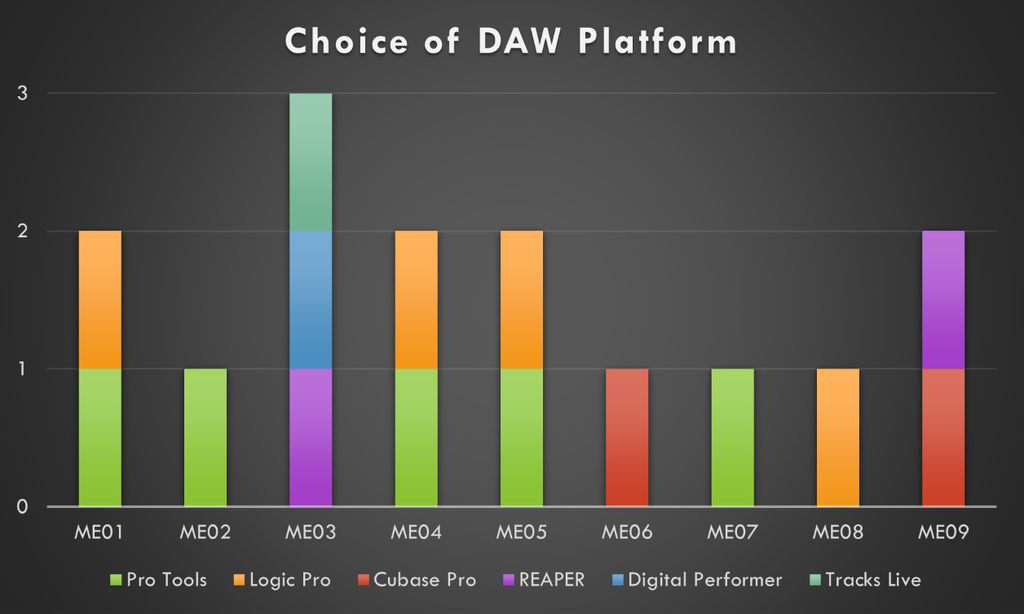

The choice of DAW platform(s) per participant

However, analysing the data further and concentrating on which DAW platform is exclusively, or predominantly, used for studio-based post-production audio mixing, *Pro Tools* is the DAW of choice for five participants, *Cubase Pro* for two and *Logic Pro* for one. ME03, who stated that when “doing some mixdown stuff, it would either be… *Digital Performer* or… *Logic* and the occasional *Pro Tools*, but not as much”, did not differentiate between *Digital Performer* and *Logic Pro*. Therefore, they have been attributed to the participant, but with a 50% weighting. Figure 2 shows this distribution of DAW platforms for studio-based audio mixing.

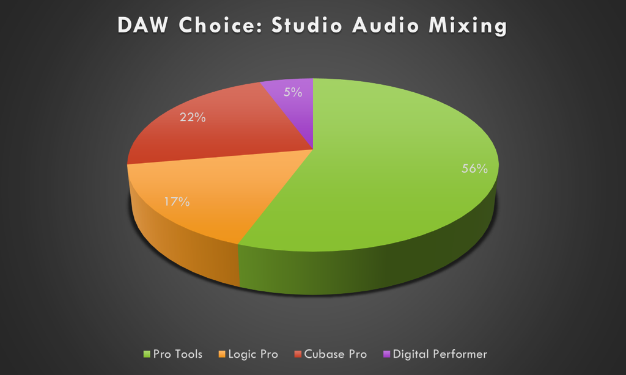

The distribution of chosen DAW platforms for studio-based audio mixing

### 2.1.3 Typical DAW Work-Case Scenarios

The participants discussed three discrete music production activities, for which their chosen DAW platform(s) played an integral role:

1. Studio-based audio recording;
2. Studio-based post-production audio mixing; and
3. Live multitrack audio recording.

The audio material requiring post-production mixing was sourced mainly from either studio recording sessions conducted by the participant or from clients with audio files recorded elsewhere. In addition to these activities, ME01 discussed post-production audio mixing for film by importing video and specific DAW export file formats into a *Pro Tools* session:

> “They send me film, and they also send me an AAF [Advanced Authoring Format file] or an OMF [Open Media Framework file], which is out of their editing [software] … It has volume, gain clip… sometimes it has panning… but the main thing is all the audio is locked in with the film, and it’s very… frame-accurate.” -ME01

However, mixing for this medium appears to be a specialised practice considering only one of the nine participants mentioned this facet of post-production audio mixing. Furthermore, the two live mixing engineers discussed their DAW use for capturing live multitrack performances for later post-production audio mixing:

> “If you can imagine a live show that I’ve multitracked, the idea is that those tracks be turned into something that will be commercially released as a record, or… B-Sides or DVD.” -ME03

> “Anyway, that’s what I do, studio recording and post mixes, and live front-of-house mixing…, desk recordings and post-production.” -ME09

Though not expressly mentioned, the engineers presumably export their multitrack recordings as audio stems for importing into the DAW platform better suited for such work than the one employed to capture the recordings.

Interestingly, some of the participants, who engage in post-production audio mixing of source material recorded outside of the participants’ studios, expressed a reluctance or apprehension when approaching this type of music production work:

> “Yeah, I… do a little bit of that, but most of the stuff I record here. I just want to hear [the recorded material] first because oftentimes I find people’s expectations if they’ve recorded at home and it’s… terribly recorded… they think that sending it to me it’s going to sound like a Foo Fighters album or something, which is obviously not the case. -ME02

> “The bulk of my work is recording and post mixing. I have done just some post mixing of tracks produced elsewhere, but… I prefer not to work that way…. I don’t mix a lot of other people’s studio work… it’s a challenge when I do, which I suppose is not that bad, but it takes more time that I don’t always have or could be better spent doing other work.” -ME05

Conversely, ME07, who works as a freelance audio mixing engineer, specialises in mixing recordings produced by other audio engineers, and ME08 expressed enjoyment in such mixing work:

> “As for the type of work I do, it’s pretty much freelance post-production mixing.” -ME07

> “I occasionally get some post-production work thrown my way, which I really enjoy actually.” -ME08

Given such divergent responses, it appears that whether a mixing engineer works with audio they did not record or not comes down to a personal preference.

## 2.2 Prevailing Use of Keyboard Shortcuts and Control Surfaces

This question queried the participants using two existing methods of remotely operating a DAW application: keyboard shortcuts and control surfaces. The reasoning for this particular line of inquiry was to establish if using such methods was inherent in the participants’ established work routines.

All nine participants emphasised their use of keyboard shortcuts as being integral to their workflow, attributing the expediency their usage provides:

> “Keyboard shortcuts, for anyone who has been producing for a while, are like the”golden child” in every studio. Everyone has their own ones, and they save you so much time.” -ME01

> “I use the shortcuts; if… there’s something that I’m doing… in Pro Tools, I’m like, ‘That could be a lot faster’, then I’ll look for a shortcut. Most of the things that I need I have shortcuts.” -ME02

> “I use keyboard shortcuts all the time; in fact, I can’t imagine how I worked before them. The more I don’t have to touch the mouse, the more I don’t have to take time finding some command in a menu, the better.” -ME05

> “Keyboard shortcuts streamline my workflow and makes setting up a project so much quicker than using a mouse.” -ME06

Six participants mentioned they had integrated a control surface configuration into their extended DAW architecture. The reasons given for why the participants included the use of a control surface into their workflow were twofold: for the tactile operation when automating DAW-specific events, and for the perceived superiority and ease compared to using a mouse:

> “When you’re automating something by [a mouse], it’s a lot different to when you’re moving it by feel, by your hands. So, I think [there are] definitely advantages to [control surfaces], and… when I’m mixing a song and doing something creative, I’ll use faders.” -ME01

> “Maybe it’s just that I came up from the old-school of physical consoles: knobs, buttons, switches and faders. That is definitely my comfort level… the world of automation… roughing things in if you like…. I always prefer to have something that reflects [my hands] rather than a mouse.” -ME03

> “Right now, I use the [Avid] S3, and I don’t know how I got on without it… it has all the control I need right there, and I find myself looking less and less at the mixer on-screen…. I really like the feel of faders under my fingers. It makes me feel like I’m still keeping in touch with what mixing has always been about: … things you can touch and move while you listen.” -ME05

> “I’ve also been using a Mackie MCU and MCU Extender control surface set-up for the past 5 or 6 years…. I like the… tactile response I get from real faders and rotary encoders when I’m mixing.” -ME06

Interestingly, at the time of the interviews, some of the participants who did not employ a control surface expressed a desire to do so in the future, suggesting that such devices, and their use in audio mixing activities, are becoming *de rigueur*.

## 2.3 Experience with Existing DAW-Integrated Collaboration Features

Of the nine participants interviewed, seven worked with DAW platforms that feature integrated online collaboration features. *Pro Tools* users can access the asynchronous file and project sharing feature, *Cloud Collaboration*. In contrast, the *Cubase Pro* users have two collaborative options, the synchronous remote performer recording system, *VST Connect*, and the asynchronous file and project sharing approach facilitated by *VST Transit*. Given that these seven participants had a readily available means of online collaboration provided by their DAW platform, it was helpful asking them about their level of familiarity and practical experience with these two forms of collaboration to determine their current degree of engagement in such activities.

### 2.3.1 Avid’s Pro Tools: Cloud Collaboration

Of the five participants who used *Pro Tools* for their post-production audio mixing work, four said they had not used *Cloud Collaboration*, and even then, the one participant who had, ME04, had only tried it once. Furthermore, ME07 was not particularly aware of its existence:

> “I haven’t used it at all. It… vaguely sounds… familiar, you know, I may have read something or heard someone… I really can’t imagine why I’d use it, to be honest.” -ME07

As to why the four participants who were familiar with *Cloud Collaboration* chose not to use it, their responses derived several themes:

### 2.3.2 Steinberg’s Cubase Pro: VST Connect and VST Transit

#### 2.3.2.1 VST Connect

Both participants who chose to utilise Cubase Pro for their studio-based audio mixing also employed *VST Connect* for its real-time remote performer recording capability. ME06 and ME09 noted the importance of an accessible high-speed Internet connection, something that, in Australia, has only been available since the mid-2010s (Gregory, 2019):

> “The first time I did use [VST Connect] was to record a guitarist… [in] 2014 or 15… using VST Connect SE… and it didn’t work all that well. There were just too many dropouts for any of it to be useful. I did revisit it, though, when I got… a 50 Mbps connection and… the Pro version of VST Connect…. This time I used it to record vocals, and it worked really well.” -ME06

> “When Steinberg came out with Connect Pro… I was sceptical… It wasn’t till I got [high-speed broadband] connected that I investigated it a little more, and I was… really surprised at the automatic configuration.” -ME09

Both participants acknowledged that they still encounter sporadic jitter and audio dropouts with the performer’s streamed audio; however, the Pro version of *VST Connect* provides post-session transmission of a high-resolution audio recording of the performer, stored on the performer’s computer, which automatically replaces the streamed audio in the *Cubase Pro* project. The participants pointed to this functionality as a highly-valued feature:

> “I also got the Pro version of VST Connect, even though it cost me to do it, mainly because [it] could let you transfer a high-quality recording of the performer to replace the live-streamed version after the recording session.” -ME06

The participants mentioned *VST Connect’*s video communication as a positive way to interact with the remote performer, distinguishing it from other similar collaboration platforms:

> “The video is great, too; I didn’t have that with [an alternative remote recording platform]. Yeah, it’s a really useful add-on to have.” -ME09

#### 2.3.2.2 VST Transit

In stark contrast to the participants’ uptake of *VST Connect*, neither of them chose to use the *VST Transit* method of collaboration, mirroring the response received by those participants who utilise *Pro Tools*. Again, the dominant reason behind their decision owes to the similarity in functionality with the participants’ existing remote collaboration practices co-opting existing third-party cloud storage solutions and the extra cost of additional storage capacity:

> “With VST Transit, I’ve also checked it out, but it’s really similar to just using Dropbox to share your files…. I guess it’s another way for people to connect, but it’s not something I really need considering I’m already paying for a Dropbox subscription.” -ME06

> “[VST Transit is] just another cloud storage and sharing thing that I do already using Dropbox or Google Drive. I don’t really need to share my recordings with anyone; I just send a mix.” -ME09

ME09 identified a similar issue with *Pro Tools* and *Cloud Collaboration*, in that collaborating with *VST Transit* requires the other collaborators also to have a recent version of *Cubase Pro* to access the project and audio files:

> “From what I can tell, [VST Transit is] a way to share your Cubase projects, and I don’t know too many other people also using Cubase, which, um, kind of makes it unnecessary, really.” -ME09

However, *VST Transit Join* (Steinberg Media Technologies GmbH, 2021b) is a more recent add-on to *VST Transit* that allows collaborators with DAW platforms other than *Cubase Pro* to access and contribute to the shared *Cubase Pro* project.

## 2.4 Existing Remote Collaboration Practices

- *Dropbox*;
- *Google Drive* (Google LLC, 2020);
- *WeTransfer* (WeTransfer, 2021); and
- *iCloud* (Apple Inc., 2021b).

Interestingly, cloud-based applications designed explicitly for DAW project backup, version cataloguing and rollback and remote collaboration, such as *Splice Studio* (Splice.com, 2022), were not mentioned. It could well have been that the participants were unaware of such platforms or, as seen with *Cloud Collaboration* and *VST Transit*, their similarity to existing cloud storage platforms precluded their adoption.

Figure 3 shows the range and choice of cloud storage options across eight of the nine participants. Note that ME03 did acknowledge the ease of file sharing today but did not mention any particular platform.

In addition to cloud storage, some of the participants discussed a secondary collaboration means of communicating with clients, for instance, a third-party videoconferencing platform:

> “I’ve had situations where I’ve actually got advertising clients overseas via Skype, dialled in listening to the voice-over session live…. They just want to make sure that the voice-over is what they want… and I’m just a puppet here pressing buttons.” -ME01

> “I would chat to them, have a Zoom chat, and then just do my mixing and send the mix back and go back-and-forth.” -ME04

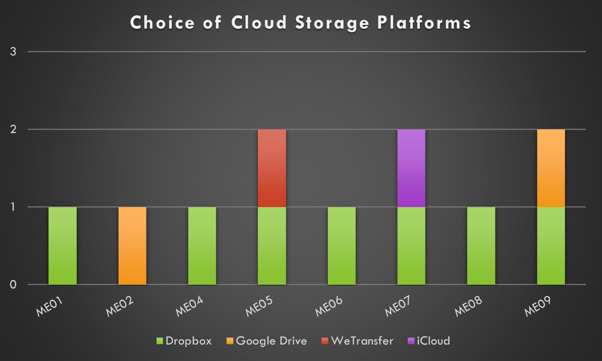

The choice of cloud storage platform(s) per participant

Furthermore, some collaborators still prefer to use written instructions and feedback through the exchange of emails, while others will speak to the client directly over the phone:

> “If it’s a band [I am mixing], I always say, ‘You guys discuss it as a band, and then one person, I’ll deal with one person only, you email me back and forth, and we can discuss whatever problems’.” -ME02

> So, again, Dropbox is the way to go and either speak on the phone or email for any edits.” -ME06

> “Really, it’s just as simple as uploading the mix once I think it’s ready and usually a phone call to the client to go over what I’ve done and work out if there’s any changes needed.” -ME09

However, irrespective of the chosen means, it is apparent that once an audio mix is shared, the mixing engineer requires a reciprocal mode of communication with the client(s) to develop the mix further and ensure the final product meets expectations. File sharing via cloud storage is only one part of the equation contributing to a collaborative mixing effort.

One of the significant facets of the participants’ asynchronous collaborative approach is the iterative, back-and-forth nature of their interactions, communications, and ultimately, the audio mix development. Some acknowledged that this methodology is not ideal; however, given the uniform approach to remote collaboration, it appears to be accepted as an industry-standard way of working:

> “So, I’ll prepare the session once we’ve got a file that’s okay… I’ll just send them a bounce of the… song, give them the [tempo] so they can load it into whatever [DAW] they’re using, they record the parts from zero, and then they send those back.” -ME01

> “The collaboration of sending files back and forth constantly, it’s a lot easier these days than it used to be. There used to be a time when we would literally ‘Fed-Ex’ hard drives over to them, over ‘the pond’ because it was easier than trying to do it online.” -ME03

> “I would chat to them, have a Zoom chat, and then just do my mixing and send the mix back and go back-and-forth.” -ME04

> “So… Dropbox works, but it’s a slow and a repetitious way of working, especially when I can make… remote recordings in the studio.” -ME06

## 2.5 Professional Expectations of a Real-Time Remote Collaboration Environment

When asking the participants to provide a wish-list of capabilities, features and environmental conditions of an idealised and hypothetical real-time remote audio mixing or music production collaborative milieu, some needed clarification to conceptualise the environment readily:

> “Okay, so, like, I’m working in here on Pro Tools, and I’m connecting to someone else at the same time? Is that what you mean? Sorry, this is a real curveball [because] it’s something I’ve never thought about… and correct me if I’m wrong, it’s something we’ve never been able to do, right?” -ME05

> “Right, so, just to be clear, you’re talking about working online with a client, not a client working with you in the studio…. This is not like [VST] Performer? You’re not talking about remote recording?” -ME09

Despite the hesitant start for some, the participants’ responses revealed some common themes. Chief among them was the need for clear and effective communication. Indeed, several participants articulated a desire for an audio/visual communication link, preferring the spoken word over a text-based chat feature:

> “They have to be able to hear me the whole time. I’d love to be able to see what’s going on… a good talkback system, real-time, and vision of what’s going on.” -ME01

> “I would want to have a video link, so… they can see me, and I can see them. I’d want to have a separate audio track that’s… just a link that I can talk to-and-fro to the client.” -ME02

> “I want to know what the other person is doing, so I’d definitely want to be able to see and speak to the person as we work… I’d want to see what the other person is doing and talk through what’s happening… like what would happen if I had that person working with me.” -ME05

> “I think we’d both need to talk to each other as we go about working. If we’re developing a post-production mix, let’s say, then it’s important that we can talk through what’s needed and how to execute those moves.” -ME09

Similarly, some of the participants nominated a high-quality audio monitoring capability as a critical aspect of the collaborative environment, linking their ability to mix at an industry-standard level of expertise with their ability to hear the mixing project in as high a resolution as they would in a studio environment:

> “I want to hear what’s going on, be able to give them directions, so it has to be very clear. So, [a] very clear monitoring path.” -ME01

> “I continue to monitor the mix in the studio the same way, not some glitchy audio streamed from the other person. I want to hear the mix the way it sounds coming straight from the DAW.” -ME05

> “I’d want it to run like we’re both there at the mixer console hearing the same thing as we mix…. But you’d want to hear what the other person is doing as though you’re both in the same listening environment and working with the highest audio resolution… as you would in your own studio.” -ME06

> “Okay, well, first up, I need to hear the mix in optimal conditions.” -ME07

Several participants not only expressed their vision of the collaboration involving the use of a DAW platform, but they also articulated a desire to maintain their usual degree of localised control over that DAW’s operation. Some of the participants appeared to harbour concern over losing creative control of the mixing project and wanted to ensure that they could preserve a professional mixing standard:

> “I’d want to keep using Pro Tools exactly the same way I use it now. I’d want to be able to control what happens and not have someone else make changes that I don’t know about until the session’s updated.” -ME05

> “The most obvious thing would be that I continue to use Cubase the way I currently have it configured. I wouldn’t… like having to import the stems into another type of DAW just to do the collaboration. I’d want to make sure I’ve got control over the DAW…. I’d like to know I still have the same level of control over the project.” -ME09

Suppose there is a theme that eloquently encapsulates the broad vision of the participants as a cohesive group of professional practitioners. In that case, it is the hope for the collaborative environment and functionality to closely resemble the experience of being in the one studio space together:

> “It’s got to be like I was sitting there in the studio… Basically, everything that I would get by sitting there in the studio, I would want that.” -ME01

> “Like what would happen if I had that person working with me… in here, in the studio.” -ME05

> “I’d want it to run like we’re both there at the mixer console hearing the same thing as we mix.” -ME06

> “You’d really want it to be like you’re in the studio together.” -ME07

> “If I could have an environment that’s as close to the experience of two people working in the studio together, I think that’s the best you could wish for.” -ME09

## 2.6 Demand for Multiparty Remote Collaboration

The participants were not as unified in response to being asked to provide an opinion on the apparent worth of conducting a remote collaboration session with multiple parties as they responded to the previous question. Two participants did recognise the value in collaborating within a multiparty environment:

> “What… often happened with me was, just purely by fact of geography, the bands I was working with are US-based, and I was Australia-based, so I was only over there during tours, typically. I wouldn’t be able to be in the studio if they’re grabbing multitracks and potentially doing some overdubs…. There were often situations where another engineer would take over locally because they could be in the room with the band working one-on-one. They would be listening to what I put down cause it’s live, and they would be asking questions about how I got that, how I treated the audience mics for the stems that I’ve sent and how I’ve got certain sounds, how I cleaned up certain things…. It was difficult because it always had to be done verbally; there was no easy way that I could demonstrate it. Doing something remotely where I can… input directly into what they’re listening to would have been huge.” -ME03

> “Actually, thinking about it, I can see maybe in TV or film post that would work… a professional team who know what they’re doing: the editor, foley, sound designer. That would be good.” -ME05

Nevertheless, the general impressions gleaned from the remaining participants’ responses were that they either could not conceive of a situation in their current practice when such a collaboration would be necessary or believed a multiparty collaboration would be unworkable:

> “I’m not really sure why you’d want to [collaborate with multiple parties] … it could get messy the more people you have moving faders and so on.” -ME06

> “I’ve done plenty of mixing with the band in the control room with me, but they’re not sitting at the console moving faders with me…. I could handle working one-on-one with someone who knows what they’re doing, but I don’t think working in a group would be all that productive, really.” -ME07

> “I really don’t think that kind of thing would be necessary. I can see the value of working with a client because that’s the kind of work I do, but I really don’t think I’d use any kind of group collaboration.” -ME08

> “You’d want to make sure everyone knows what they’re doing; otherwise, it could get really messy, really quick. I suppose there could be a time and place for such a thing, but I think that might be stretching the boundary a bit.” -ME09

# 3 Discussion

There are several crucial findings evident in the totality of responses from the nine participating audio engineers:

## 3.1 The DAW Platform

While, undoubtedly, Avid’s *Pro Tools* appeared to be the most popular platform of choice, it was by no means the only one that studios and engineers adopted for their audio mixing activities. Indeed, when concentrating specifically on the DAW platforms utilised in professional audio mixing practices, the data showed that, in addition to *Pro Tools*, Steinberg’s *Cubase Pro*, Apple’s *Logic Pro* and MOTU’s *Digital Performer* appeared to serve the engineers’ required purposes equally as well.

An industry-based inquiry, conducted in 2017 by Ask.Audio, a website resource for “digital music makers” (Sethi, 2018), reflected this pattern of DAW use. 30,611 survey responses determined the top-12 primary-use DAW platforms, according to the musicians and producers who participated. The fact that a top-12 exists illustrates the breadth of the global DAW market; nevertheless, the four applications with the highest userbase were: *Ableton Live*, *Logic Pro*, *Pro Tools* and *Cubase* (see Figure 4). This result aligned with the interview data and pointed to a degree of commonality in utility and capability across the most universally used DAW platforms.

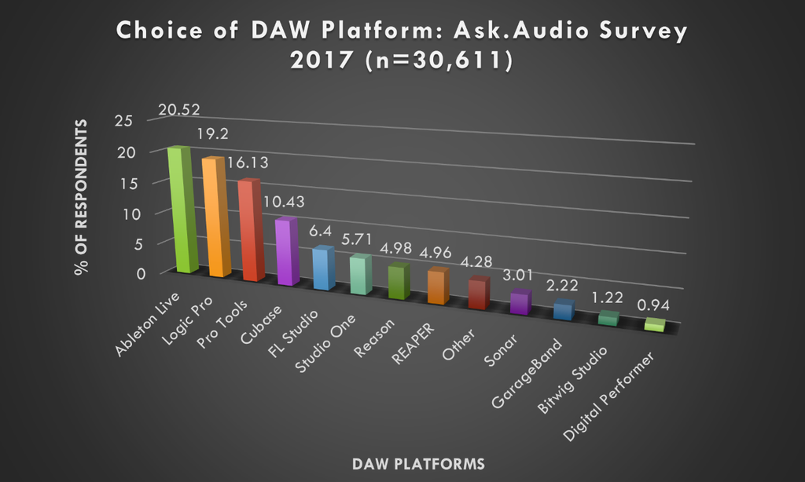

The results of Ask.Audio’s survey on the respondents’ choice of DAW platform (Adapted from (Sethi, 2018))

## 3.2 The Prevailing Use of Keyboard Shortcuts and Control Surfaces

The prevalence and intrinsic use of keyboard shortcuts, evidenced in the participants’ responses, spoke to the importance of time-efficient and expedient audio mixing processes. Similarly, the participants’ responses pointed to a current or intended addition of a control surface to their typical DAW operation and mixing practices, again iterating the advantages of their use.

## 3.3 The Uptake of DAW-Specific Remote Collaboration Features

Taking an overarching view of the interview responses, the most prominent finding was, of those participants whose chosen DAW platform included a specific asynchronous file and project sharing capability by way of specialised cloud storage, not one utilised this DAW-integrated collaboration feature. However, it would be misleading to conclude that the participants eschewed this mode of collaboration. Indeed, in most cases, this lack of uptake is owed to the participants having already adopted a form of asynchronous collaboration with clients that co-opts third-party, commercial cloud storage platforms.

Consequently, the interview responses offered an impression that professional studios and engineers are already engaged in remote collaboration practices; however, the model implemented is asynchronous, iterative and has the potential to be time-consuming and inefficient. While some participants admitted that this practice was not an ideal use of their time, and others remarked on the simplicity of the approach for working with clients outside of the studio environment, only one, ME01, described a synchronous means of remote collaboration, in this instance, running a concurrent videoconferencing application while conducting an in-studio voice-over session.

## 3.4 Industry Expectations of Real-Time Remote Music Mixing and Production Collaboration

Asking participants to enumerate the prominent features and capabilities a hypothetical “ideal” real-time remote collaborative environment provided the following shortlist of features:

1. A clear, practical and synchronous audio/visual means of communication, available to all collaborators throughout the session;
2. The ability to monitor the collaboration’s mixing and production activities in the highest fidelity possible, preferably, the exact resolution as that typically monitored in-studio;
3. DAW-based mixing and production operations, providing control over the changes and edits made to the DAW project; and
4. A collaborative environment and mode of operation that closely aligns with the experience of working in person in the studio.

## 3.5 The Perceived Utility of Remote Multiparty Music Mixing and Production Collaboration

Most of the participants’ responses did not support the need for a multiparty capability. However, ME03 favoured a collaborative environment inclusive of multiple parties, providing a post-live recording scenario that would benefit from remote multiparty collaboration. Such an instance can be considered a specialised facet of live mix engineering, not typical of local studio-based work; therefore, it was not necessarily surprising that some participants could not conceive of a situation where multiparty collaboration would be required. Indeed, some participants supposed that such collaboration would be chaotic and not especially conducive to a cohesive workflow.

# 4 Conclusion

This article presented a qualitative research study that phenomenologically analyses the current use of DAWs, their role in audio mixing and post-production, features used for remote collaboration and current professional practices. After conducting semi-structured interviews with nine Australian-based professional audio mixing engineers, the study involved collecting, interpreting, and presenting the data. Accordingly, the study resulted in the identification of several significant inductive insights.

DAWs play an integral role in professional audio engineers work and practice, with Pro Tools being the most popular platform. Typical DAW use includes activities, such as studio-based audio recording, studio-based post-production audio mixing and live multitrack audio recording. Although audio mixing is a collaborative process, and some DAW platforms provide native collaborative features, practitioners tend not to use these features in typical day-to-day work. Several reasons, including costs, such as license fees, force the participants to use a single DAW platform by all collaborators. The availability of alternate cost-effective cloud storage solutions (such as Dropbox) that can provide facilities for audio file-sharing make such features redundant. Audio mixing with remote clients by professionals typically entails sharing audio files/recordings by an audio engineer, who mixes and provides audio files for review and feedback. This method can be an iterative process. Professional audio engineers did not envision a need for multi-party remote collaboration. Instead, several participants perceived this approach as chaotic, leading to the audio engineer losing control of the project. When queried for an “ideal” remote collaborative environment for audio mixing, a unique insight was that audio engineers envision it to be an experience similar in “look and feel” to the participants working in the “same” studio. That is, all collaborators communicate synchronously, comparable to an in-studio experience. The audio mixing actions of any collaborator are viewed in “real-time” by all and played in high-resolution using the studio’s equipment. The “virtual studio” experience in remote collaboration is similar to an in-studio experience. Given the trend the participating engineers suggest, any future endeavours for a remote collaborative environment could consider achieving this goal.

# 5 References

Ableton AG (n.d.). Live (Version 11) [Computer Program]: Ableton AG. Retrieved 1 August 2021, from https://www.ableton.com/en/live/

AmpTrack Technologies AB. (2021). Make music online - Amped Studio online sequencer. Retrieved 1 August 2021, from https://ampedstudio.com/

Apple Inc. (2017). What is Core Audio? Retrieved 16 June 2020, from https://developer.apple.com/library/archive/documentation/MusicAudio/Conceptual/CoreAudioOverview/WhatisCoreAudio/WhatisCoreAudio.html

Apple Inc. (2021a). GarageBand for Mac (Version 10.4.3) [Computer Program]: Apple Inc. Retrieved 1 August 2021, from https://www.apple.com/au/mac/garageband/

Apple Inc. (2021b). iCloud. Retrieved 1 August 2021, from https://www.icloud.com/

Apple Inc. (2021c). Logic Pro (Version 10.6) [Computer Program] Cupertino, United States of America: Apple Inc. Retrieved 28 July 2021, from https://www.apple.com/au/logic-pro/

Audiotool.com. (2021). Audiotool - Free Music Software - Make Music Online In Your Browser. Retrieved 1 August 2021, from https://www.audiotool.com/

Avid Technology Inc. (2021). Pro Tools (Version 2021.6) [Computer Program] Burlington, United States of America: Avid Technology Inc. Retrieved 28 July 2021, from https://www.avid.com/pro-tools

BandLab Technologies. (2021). BandLab: Make Music Online. Retrieved 1 August 2021, from https://www.bandlab.com/

Cockos Inc. (2021). REAPER (Version 6.33) [Computer Program] New York, United States: Cockos Inc. Retrieved 18 December 2020, from https://www.reaper.fm/download.php?from_reaper=1

Dropbox Inc. (n.d.). Manage Your Work More Efficiently - Dropbox Professional. Retrieved 1 August 2021, from https://www.dropbox.com/pro

Google LLC. (2020). Google Drive: Free Cloud Storage for Personal Use. Retrieved 7 March 2020, from https://www.google.com/drive/

Gregory, Mark A. (2019). How to Transition the National Broadband Network to Fibre To The Premises. *Journal of Telecommunications and the Digital Economy, 7*(1), 57-67. DOI: 10.18080/jtde.v7n1.182

Mark of the Unicorn Inc. (2021). Digital Performer (Version 11) [Computer Program]: Mark of the Unicorn Inc. Retrieved 1 August 2021, from https://motu.com/en-us/products/software/dp/

Sethi, Rounik. (2018). Top 12 Most Popular DAWs (You Voted For). *Ask.Audio*. Retrieved 2 August 2021, from https://ask.audio/articles/top-12-most-popular-daws-you-voted-for

Smith, Jonathan A. (2004). Reflecting on the development of interpretative phenomenological analysis and its contribution to qualitative research in psychology. *Qualitative Research in Psychology, 1*(1), 39-54. DOI: 10.1191/1478088704qp004oa. https://www.tandfonline.com/doi/abs/10.1191/1478088704qp004oa

Splice.com. (2022). Collaborate with Splice Studio | Splice. Retrieved 4 February 2022, from https://splice.com/features/studio

Spotify USA / Spotify AB. (2021). Soundtrap - Make music online. Retrieved 1 August 2021, from https://www.soundtrap.com/

Steinberg Media Technologies GmbH. (2020). Technologies | Steinberg. Retrieved 17 June 2020, from https://www.steinberg.net/en/company/technologies.html

Steinberg Media Technologies GmbH (2021a). Cubase Pro (Version 11.0.3) [Computer Program] Hamburg, Germany: Steinberg Media Technologies GmbH. Retrieved 11 November 2020, from https://new.steinberg.net/cubase/new-features/

Steinberg Media Technologies GmbH. (2021b). VST Transit: Music cloud collaboration | Steinberg. Retrieved 1 August 2021, from https://new.steinberg.net/vst-transit/

wac2017 qmul. (2017). *Web Audio Conference 2017 (WAC2017 QMUL) Day 1 - Afternoon* [Video File] Retrieved 2 June 2020, from https://www.youtube.com/watch?v=OpUeyRRPpCo&feature=youtu.be&t=957

Waves Audio Ltd. (2021). Tracks Live - Multitrack Recording Software | Waves. Retrieved 1 August 2021, from https://www.waves.com/mixers-racks/tracks-live

WeTransfer. (2021). Products | WeTransfer. Retrieved 1 August 2021, from https://about.wetransfer.com/products/

# 6 Appendix: Interview Guide Questions

## 6.1 Question One:

What DAW platform do you use for your typical music production activities, and what do those activities involve?

## 6.2 Question Two:

How integral are keyboard shortcuts and/or the use of a control surface to your workflow, and why?

## 6.3 Question Three:

If the chosen DAW platform is either Pro Tools or Cubase Pro, have you had any experience using their integrated collaboration features (i.e. Cloud Collaboration, VST Connect Pro/VST Connect Performer, and VST Transit/VST Transit Join)? If so, how did you use the feature, and what are your impressions?

## 6.4 Question Four:

Have you had any experience collaborating on a music production project with a remote studio or participant? If so, how was that achieved, and what are your impressions?

## 6.5 Question Five:

If you wanted to collaborate on a music production project with a remote engineer/producer in real-time, what would be your wish-list in terms of functionality and workflow? (For example, access to the DAW project, communication means, creation and quality of audio files, or editing capabilities).

## 6.6 Question Six:

If not already mentioned, how useful would it be to extend this collaboration functionality and workflow to multiple remote engineers/producers in real-time? If so, in what way?